# (Fordgobike data explanation)

## Dataset Overview

> This dataset contains information about individual rides made in a bike-sharing system covering the greater San Francisco Bay area.

## (The generation which use the bike share system most)

> This gragh decribe the most generation use the bike sharing system,which is 1980s with count more than 60000 users use the bike sharing system

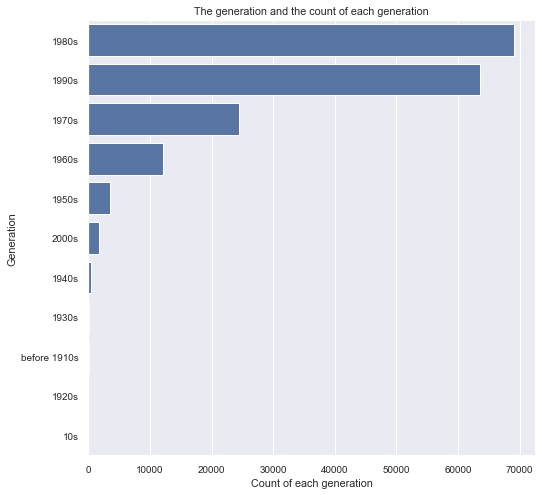

```python
year= df.member_birth_year.value_counts().index
fig_dims = (8,8)
fig = plt.subplots(figsize=fig_dims)
base_color=sb.color_palette()[0]
ax=sb.countplot(y='member_birth_year',data = df , color=base_color,order=year)
ax.set_title('The generation and the count of each generation')
ax.set(xlabel='Count of each generation', ylabel='Generation');
```

## (The most starting point the users start their trip)

> The most starting point the users start their trip is (Market st ar 10th st) with more than 3500 times

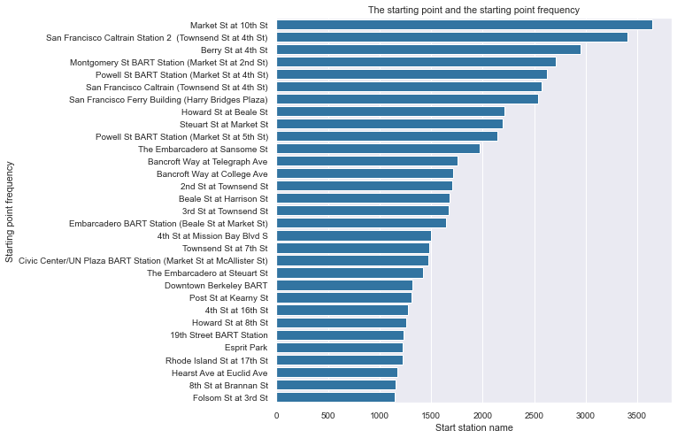

```python
start=df['start_station_name'].value_counts().index[0:31]
fig_dims = (8,8)
fig = plt.subplots(figsize=fig_dims)
ax=sb.countplot(y='start_station_name',data = df , color=base_color,order=start)
ax.set_title('The starting point and the starting point frequency')
ax.set(xlabel='Start station name', ylabel='Starting point frequency');
```

## (The most end station point )

> The most end station point the users reached is (San Francisco Caltrain Station 2 (Townsend St at 4th St) ) with more than 4000 times

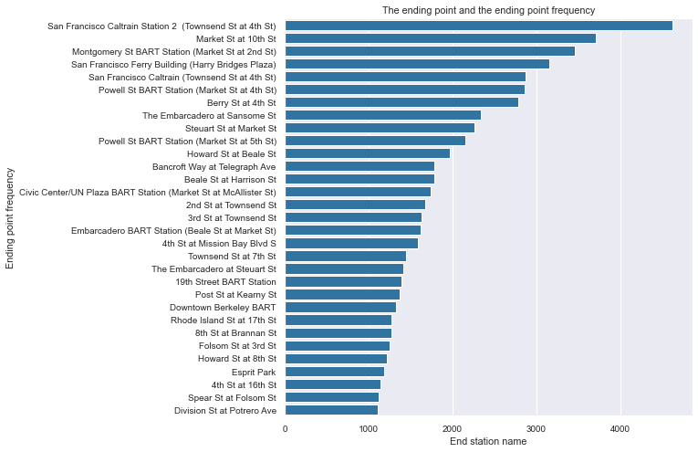

```python
end=df['end_station_name'].value_counts().index[0:31]
fig_dims = (8,8)
fig = plt.subplots(figsize=fig_dims)
ax=sb.countplot(y='end_station_name',data = df , color=base_color,order=end)
ax.set_title('The ending point and the ending point frequency')
ax.set(xlabel='End station name', ylabel='Ending point frequency');
```

## (The users type)

> There are two types of the user type, the first one is the subscriber with is more than the second one which is the customer.

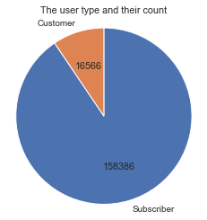

```python
#type of member
sorted_counts = df['user_type'].value_counts()
plt.pie(sorted_counts, labels = sorted_counts.index, startangle = 90, counterclock = False,autopct=autopct_format(sorted_counts))
plt.axis('square')
plt.title('The user type and their count');
```

## (The user type which spent more in duration of the trips)

> The customers spent more in duration of the trips than the subscriber with in average more than 1200 seconds

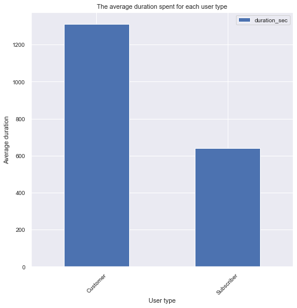

```python
#to visualize
s=df.groupby('user_type').duration_sec.mean()
s=s.to_frame()
sb.set(font_scale=0.9)
fig, ax = plt.subplots(figsize=(8,8))
ax=s.plot(ax=ax,kind='bar',rot=45)
ax.set_title('The average duration spent for each user type')
ax.set(xlabel='User type', ylabel='Average duration');
```

## (Is bike sharing has an affect on average distance covered through the whole weekdays?)

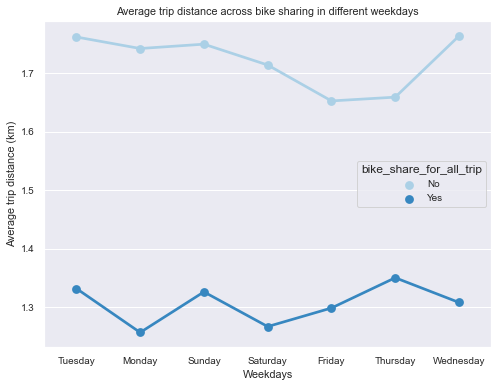

```python
fig = plt.figure(figsize = [8,6])
sb.pointplot(data = df, x = 'sday', y = 'Distance_of_trip', hue = 'bike_share_for_all_trip', palette = 'Blues', ci=None)
plt.title('Average trip distance across bike sharing in different weekdays')
plt.ylabel('Average trip distance (km)')
plt.xlabel('Weekdays')
plt.show();
```

## (Is bike sharing has an affect on average duration spent in the trips through the whole weekdays?)

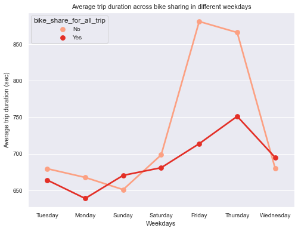

```python
fig = plt.figure(figsize = [8,6])
sb.pointplot(data = df, x = 'sday', y = 'duration_sec', hue = 'bike_share_for_all_trip', palette = 'Reds', ci=None)
plt.title('Average trip duration across bike sharing in different weekdays')
plt.ylabel('Average trip duration (sec)')
plt.xlabel('Weekdays')
plt.show();
```

## (The gender which spent more duration through through the whole weekdays)

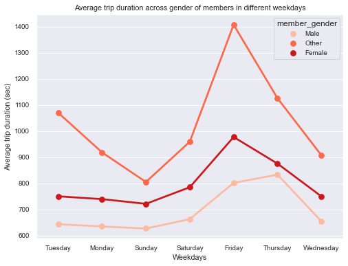

```python
fig = plt.figure(figsize = [8,6])
sb.pointplot(data = df, x = 'sday', y = 'duration_sec', hue = 'member_gender', palette = 'Reds', ci=None)
plt.title('Average trip duration across gender of members in different weekdays')
plt.ylabel('Average trip duration (sec)')
plt.xlabel('Weekdays')
plt.show()
```